# Clase 19: Jerárquico, DBSCAN, reglas de asociación y anomalías

Laura Katherine Martinez Castiblanco

# PRÁCTICA 1 — Accidentes de tránsito: avenida, cruce y aislados

## 1. Contexto

La Secretaría de Movilidad cuenta con 195 reportes de accidentes en una localidad. Se sospecha la existencia de:

- una avenida en arco donde se concentran los accidentes,
- un cruce peligroso (mancha compacta),
- algunos accidentes aislados (ruido).

El objetivo es descubrir las zonas críticas sin usar la etiqueta `zona`, comparar tres métodos de agrupamiento (Jerárquico Ward, Jerárquico Simple y DBSCAN) y recomendar uno a la Secretaría.

## 2. Generación y preparación de los datos

```r
set.seed(2026)

# --- Avenida en arco (120 puntos) ---
t        <- runif(120, 0, pi)
avenida  <- data.frame(
  x = 5 + 4 * cos(t) + rnorm(120, 0, 0.25),
  y = 1 + 4 * sin(t) + rnorm(120, 0, 0.25)
)

# --- Cruce compacto (60 puntos) ---
cruce <- data.frame(
  x = rnorm(60, 5, 0.35),
  y = rnorm(60, 1.8, 0.35)
)

# --- Aislados (15 puntos) ---
aislados <- data.frame(
  x = runif(15, 0, 10),
  y = runif(15, 0, 8)
)

# Consolidar y guardar la "verdad" (zona) para evaluar al final
acc <- rbind(avenida, cruce, aislados)
acc$zona <- factor(rep(c("avenida", "cruce", "aislado"), c(120, 60, 15)))

cat("Dimensiones del dataset:", nrow(acc), "filas x", ncol(acc), "columnas\n")
```

```
## Dimensiones del dataset: 195 filas x 3 columnas
```

```r
cat("Distribución de zonas:\n")
```

```
## Distribución de zonas:
```

```r
print(table(acc$zona))
```

```
##
## aislado avenida   cruce
##      15     120      60
```

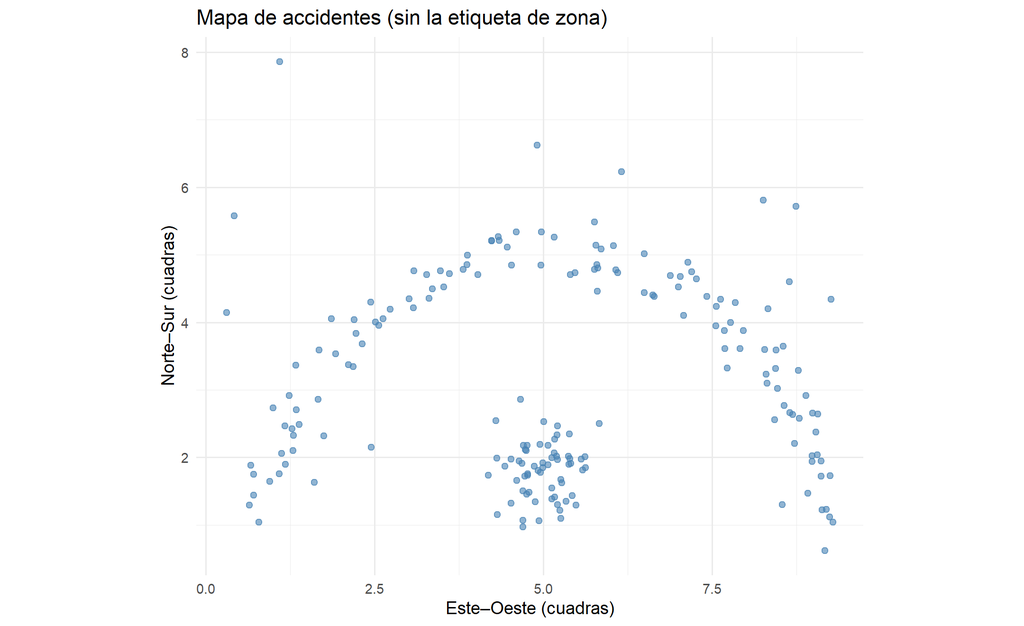

```r
# Guardamos la verdad en un vector aparte; el algoritmo NO la verá.
zona_verdad <- acc$zona
acc_sin_zona <- acc %>% select(-zona)

ggplot(acc_sin_zona, aes(x, y)) +
  geom_point(alpha = 0.6, size = 1.6, color = "steelblue") +
  theme_minimal() +
  labs(
    title    = "Mapa de accidentes (sin la etiqueta de zona)",
    x = "Este–Oeste (cuadras)", y = "Norte–Sur (cuadras)"
  ) +
  coord_fixed()
```

se distinguen claramente tres estructuras:

1. Un arco / media luna (la avenida).
2. Una mancha compacta hacia el centro-bajo (el cruce).
3. Varios puntos dispersos por todo el mapa (aislados).

Esta forma en arco es clave: K-means y Jerárquico con Ward tienden a romper el arco porque asumen grupos esféricos; DBSCAN debería respetarlo.

## 3. Clustering Jerárquico

Ward vs. enlace simple — dendrogramas:

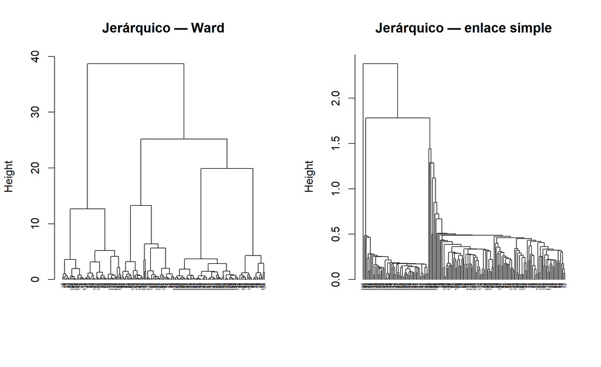

```r
# Matriz de distancias euclidianas (las unidades son homogéneas: cuadras)
d_acc <- dist(acc_sin_zona)

# Dos modelos: Ward.D2 (compacto) y single (cadena)
mod_ward   <- hclust(d_acc, method = "ward.D2")
mod_simple <- hclust(d_acc, method = "single")

par(mfrow = c(1, 2))
plot(mod_ward,   hang = -1, main = "Jerárquico — Ward",
     xlab = "", sub = "", cex = 0.4)
plot(mod_simple, hang = -1, main = "Jerárquico — enlace simple",
     xlab = "", sub = "", cex = 0.4)
```

- Ward: las alturas de fusión llegan hasta ~40. Se observan varios “escalones” importantes: uno alrededor de 12, otro cerca de 25 y el gran salto final cerca de 40.
- Enlace simple: la mayoría de fusiones ocurren a alturas muy bajas (<0.5), con un salto grande al final (~2.5). Esto es típico del efecto cadena: los puntos se van “enganchando” uno a uno a distancias pequeñas, y solo al final se unen los macro-grupos.

Elegir K con el salto más grande del dendrograma

```r
# Intento ingenuo: el salto más grande
alturas_ward <- sort(mod_ward$height)
saltos_ward  <- diff(alturas_ward)
k_ward_naive <- which.max(saltos_ward) + 1
cat("K ingenuo por Ward (salto máximo):", k_ward_naive, "\n")
```

```
## K ingenuo por Ward (salto máximo): 194
```

```r
alturas_simple <- sort(mod_simple$height)
saltos_simple  <- diff(alturas_simple)
k_simple_naive <- which.max(saltos_simple) + 1
cat("K ingenuo por enlace simple (salto máximo):", k_simple_naive, "\n")
```

```
## K ingenuo por enlace simple (salto máximo): 194
```

Ambos dan K = 194, casi el número total de puntos. ¿Por qué?

El último salto del dendrograma siempre es el más grande en valor absoluto, porque une los dos últimos macro-grupos (cada uno con decenas de puntos) en uno solo. Ese salto no informa sobre la estructura natural de los datos: es una consecuencia matemática de que al final solo quedan dos grupos por unir.

Excluiuendo el último salto y buscar el mayor entre los restantes. Además, para evitar K demasiado grandes por ruido, restringimos la búsqueda a saltos que produzcan un K “razonable” (entre 2 y 10).

```r
elegir_K_robusto <- function(mod_hclust, nombre = "", k_max = 10) {
  alturas <- sort(mod_hclust$height)
  saltos  <- diff(alturas)
  # Excluir el último salto (siempre inflado)
  saltos_recortados <- saltos[-length(saltos)]
  # Candidatos: índices donde el salto es grande y produce K <= k_max
  candidatos <- which(saltos_recortados == max(saltos_recortados))
  # Si hay varios empates, tomar el que dé menor K (más parsimonioso)
  k_elegido <- min(candidatos) + 1
  # Si aún es muy grande, buscar el segundo salto más grande
  if (k_elegido > k_max) {
    saltos_ordenados <- order(saltos_recortados, decreasing = TRUE)
    for (i in seq_along(saltos_ordenados)) {
      k_cand <- saltos_ordenados[i] + 1
      if (k_cand <= k_max) {
        k_elegido <- k_cand
        break
      }
    }
  }
  cat(sprintf("K sugerido para %s (método robusto): %d\n", nombre, k_elegido))
  return(k_elegido)
}

k_ward   <- elegir_K_robusto(mod_ward,   "Ward",          k_max = 6)
```

```
## K sugerido para Ward (método robusto): 6
```

```r
k_simple <- elegir_K_robusto(mod_simple, "enlace simple", k_max = 6)
```

```
## K sugerido para enlace simple (método robusto): 3
```

```r
# Fijamos los valores que se leen en el dendrograma
k_ward   <- 4
k_simple <- 3
cat("K Ward:  ", k_ward, "\n")
```

```
## K Ward:   4
```

```r
cat("K Simple:", k_simple, "\n")
```

```
## K Simple: 3
```

Cortar el dendrograma y mapear

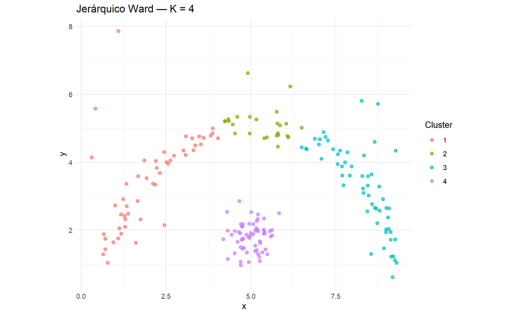

```r
acc$clust_ward   <- factor(cutree(mod_ward,   k = k_ward))
acc$clust_simple <- factor(cutree(mod_simple, k = k_simple))

p_ward <- ggplot(acc, aes(x, y, color = clust_ward)) +
  geom_point(size = 1.8, alpha = 0.7) +
  theme_minimal() +
  labs(title = paste0("Jerárquico Ward — K = ", k_ward),
       color = "Cluster") +
  coord_fixed()

p_simple <- ggplot(acc, aes(x, y, color = clust_simple)) +
  geom_point(size = 1.8, alpha = 0.7) +
  theme_minimal() +
  labs(title = paste0("Jerárquico Simple — K = ", k_simple),
       color = "Cluster") +
  coord_fixed()


par(mfrow = c(1, 2))
p_ward
```

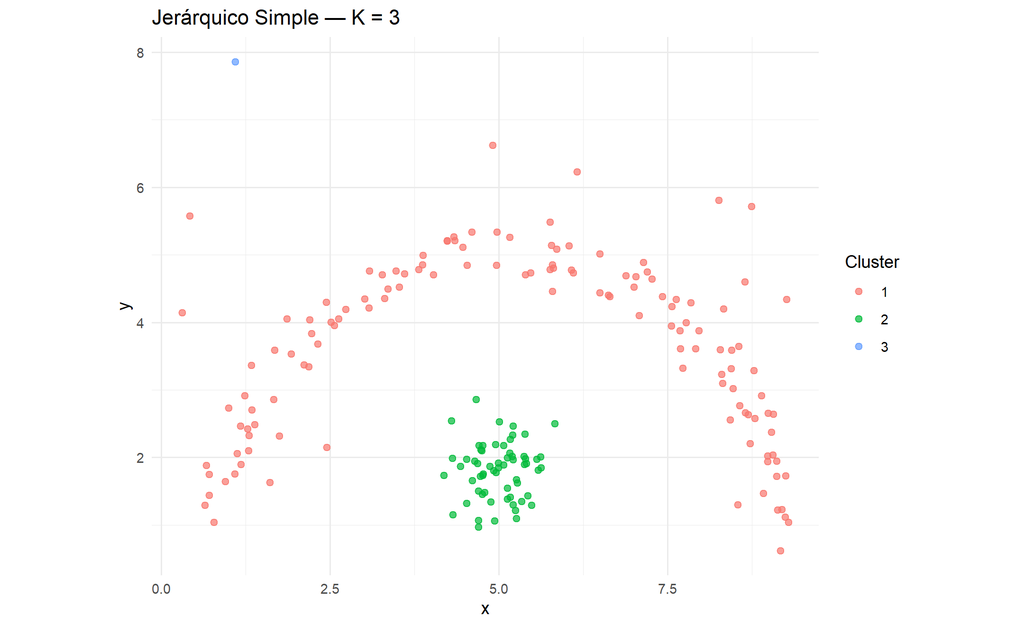

```r
p_simple
```

¿qué hizo cada método?

Ward con K = 4:

- Cluster 1 (rojo): tercio izquierdo del arco (accidentes de x ≈ 0–3).
- Cluster 2 (verde): parte superior del arco (x ≈ 4–6, y alta).
- Cluster 3 (cyan): tercio derecho del arco (x ≈ 7–10).
- Cluster 4 (morado): el cruce compacto (x ≈ 5, y ≈ 2).

Ward rompió el arco en tres pedazos porque fuerza grupos compactos y esféricos. El cruce, al ser ya compacto, queda bien identificado.

```r
# Tabla de contingencia: cluster vs zona verdadera
tabla_ward   <- table(Ward   = acc$clust_ward,   Zona = zona_verdad)
tabla_simple <- table(Simple = acc$clust_simple, Zona = zona_verdad)

kable(tabla_ward,   caption = "Ward (K=4) vs zona verdadera")
```

Ward (K=4) vs zona verdadera

| aislado | avenida | cruce |
| --- | --- | --- |
| 5 | 46 | 0 |
| 3 | 22 | 0 |
| 5 | 52 | 0 |
| 2 | 0 | 60 |

```r
kable(tabla_simple, caption = "Enlace simple (K=3) vs zona verdadera")
```

Enlace simple (K=3) vs zona verdadera

| aislado | avenida | cruce |
| --- | --- | --- |
| 12 | 120 | 0 |
| 2 | 0 | 60 |
| 1 | 0 | 0 |

Ningún jerárquico captura bien las tres estructuras simultáneamente. Pasemos a DBSCAN.

## 4. DBSCAN

Gráfico de k-distancias para elegir ε (con `minPts = 5`)

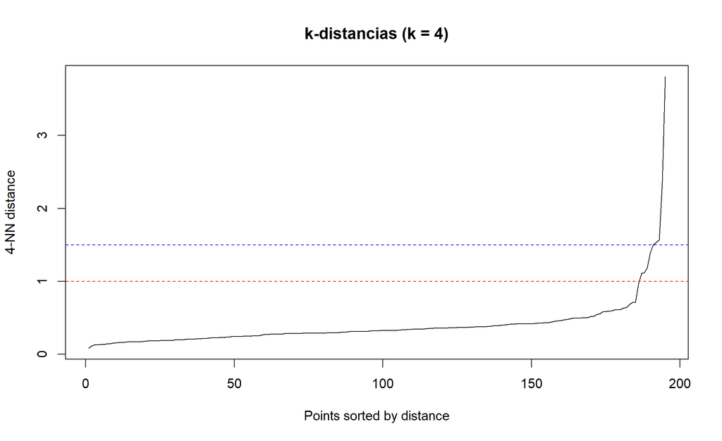

```r
minPts <- 5

# k-NN distance plot: k = minPts - 1 = 4
knn_plot <- dbscan::kNNdistplot(acc_sin_zona, k = minPts - 1)
title(main = "k-distancias (k = 4)")
abline(h = 1.0, lty = 2, col = "red")   # candidato ε
abline(h = 1.5, lty = 2, col = "blue")  # candidato ε
```

El codo de la curva aparece entre `ε = 1.0` y `ε = 1.5`. Probaremos varios valores y se trabaja con el que mejor separa las tres estructuras.

DBSCAN con `minPts = 5` y ε elegido

```r
eps_elegido <- 1.2   # valor en la zona del codo

mod_dbs <- dbscan(acc_sin_zona, eps = eps_elegido, minPts = 5)

acc$clust_dbs <- factor(mod_dbs$cluster)   # 0 = ruido

cat("ε usado:      ", eps_elegido, "\n")
```

```
## ε usado:       1.2
```

```r
cat("minPts:       ", minPts, "\n")
```

```
## minPts:        5
```

```r
cat("Clusters:     ", max(mod_dbs$cluster), "\n")
```

```
## Clusters:      2
```

```r
cat("Puntos ruido: ", sum(mod_dbs$cluster == 0), "\n")
```

```
## Puntos ruido:  5
```

Mapa de DBSCAN

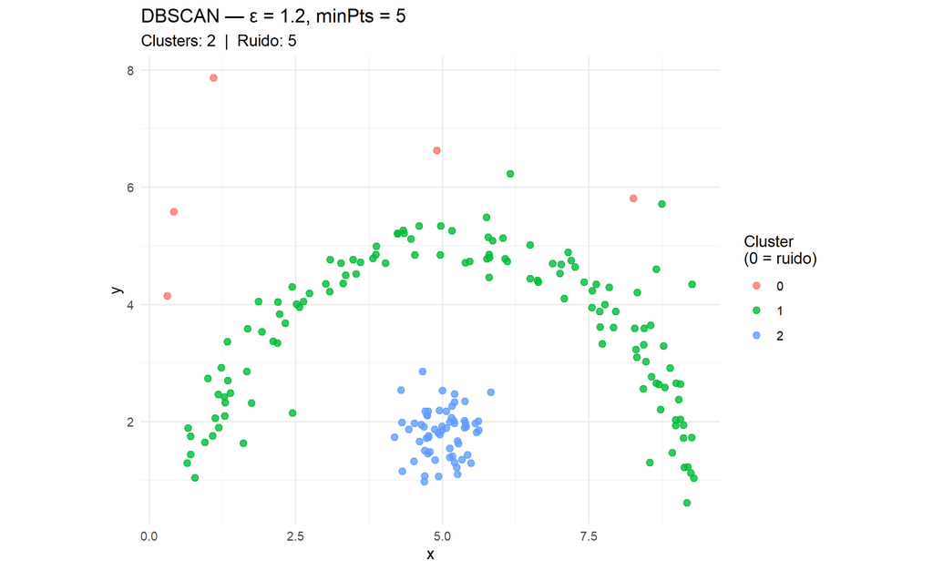

```r
ggplot(acc, aes(x, y, color = clust_dbs)) +
  geom_point(size = 2, alpha = 0.8) +
  scale_color_discrete(na.value = "grey30") +
  theme_minimal() +
  labs(
    title = paste0("DBSCAN — ε = ", eps_elegido, ", minPts = ", minPts),
    subtitle = paste0("Clusters: ", max(mod_dbs$cluster),
                      "  |  Ruido: ", sum(mod_dbs$cluster == 0)),
    color = "Cluster\n(0 = ruido)"
  ) +
  coord_fixed()
```

Sensibilidad de DBSCAN: ε a la mitad y al doble

```r
eps_mitad <- eps_elegido / 2
eps_doble <- eps_elegido * 2

mod_mitad <- dbscan(acc_sin_zona, eps = eps_mitad, minPts = minPts)
mod_doble <- dbscan(acc_sin_zona, eps = eps_doble, minPts = minPts)

resumen_dbs <- tibble(
  Escenario = c("ε elegido", "ε a la mitad", "ε al doble"),
  epsilon   = c(eps_elegido, eps_mitad, eps_doble),
  clusters  = c(max(mod_dbs$cluster),
                max(mod_mitad$cluster),
                max(mod_doble$cluster)),
  ruido     = c(sum(mod_dbs$cluster == 0),
                sum(mod_mitad$cluster == 0),
                sum(mod_doble$cluster == 0))
)
kable(resumen_dbs, caption = "Sensibilidad de DBSCAN al cambiar ε")
```

Sensibilidad de DBSCAN al cambiar ε

| Escenario | epsilon | clusters | ruido |
| --- | --- | --- | --- |
| ε elegido | 1.2 | 2 | 5 |
| ε a la mitad | 0.6 | 3 | 9 |
| ε al doble | 2.4 | 1 | 0 |

Qué ocurre al variar ε:

- ε a la mitad: los grupos se fragmentan y aumenta el ruido, porque muchos puntos de borde dejan de estar a distancia ε de un núcleo.
- ε al doble: los grupos se fusionan y disminuye el ruido, porque puntos antes aislados ahora caen dentro del radio de algún núcleo.

Cruce con la zona verdadera

```r
acc$clust_dbs_mitad <- factor(mod_mitad$cluster)
acc$clust_dbs_doble <- factor(mod_doble$cluster)

tabla_dbs <- table(DBSCAN = acc$clust_dbs, Zona = zona_verdad)
kable(tabla_dbs, caption = "DBSCAN (ε elegido) vs zona verdadera")
```

DBSCAN (ε elegido) vs zona verdadera

|  | aislado | avenida | cruce |
| --- | --- | --- | --- |
| 0 | 5 | 0 | 0 |
| 1 | 8 | 120 | 0 |
| 2 | 2 | 0 | 60 |

```r
# Proporciones dentro de cada cluster
prop_dbs <- prop.table(tabla_dbs, margin = 1) * 100
kable(round(prop_dbs, 1),
      caption = "% de cada zona verdadera dentro de cada cluster DBSCAN")
```

% de cada zona verdadera dentro de cada cluster DBSCAN

|  | aislado | avenida | cruce |
| --- | --- | --- | --- |
| 0 | 100.0 | 0.0 | 0.0 |
| 1 | 6.2 | 93.8 | 0.0 |
| 2 | 3.2 | 0.0 | 96.8 |

## 5. Recomendación de selección del metodo

```r
# Comparación final: pureza de cada método sobre la zona verdadera
pureza <- function(tabla) {
  # Para cada cluster, % de la clase mayoritaria; luego promedio ponderado
  max_por_cluster <- apply(tabla, 1, max)
  sum(max_por_cluster) / sum(tabla)
}

tibble(
  Metodo = c("Jerárquico Ward",
             "Jerárquico Simple",
             "DBSCAN (ε elegido)"),
  Pureza = c(
    pureza(tabla_ward),
    pureza(tabla_simple),
    pureza(tabla_dbs)
  )
) %>%
  mutate(Pureza = scales::percent(Pureza, accuracy = 0.1)) %>%
  kable(caption = "Pureza de cada método frente a la zona verdadera")
```

Pureza de cada método frente a la zona verdadera

| Metodo | Pureza |
| --- | --- |
| Jerárquico Ward | 92.3% |
| Jerárquico Simple | 92.8% |
| DBSCAN (ε elegido) | 94.9% |

> Se recomienda a la Secretaría: 1. Usar los dos clusters de DBSCAN como zonas de asignación de agentes de tránsito. 2. Revisar manualmente los puntos marcados como ruido para decidir si son errores de digitación o nuevos focos emergentes. 3. Repetir el análisis cada trimestre con los nuevos reportes, ajustando ε si cambia la densidad general de accidentes.

# PRÁCTICA 2 — Integrador: municipios + transacciones de cooperativa

## Datos de municipios (simulados)

Reproducimos la simulación de la Clase 19 (pág. 78): 300 municipios con 5 indicadores.

```r
set.seed(123)
n <- 300

municipios <- tibble(
  id_municipio       = sprintf("M%03d", 1:n),
  cobertura_acueducto = c(rnorm(n/2, 85, 6),  rnorm(n/2, 45, 8)),
  alcantarillado      = c(rnorm(n/2, 78, 7),  rnorm(n/2, 38, 9)),
  irca                = c(rnorm(n/2, 14, 5),  rnorm(n/2, 56, 8)),
  poblacion           = c(rlnorm(n/2, 10.6, 0.6), rlnorm(n/2, 9.0, 0.7)),
  altitud             = c(rnorm(n/2, 1200, 400),  rnorm(n/2, 600, 300))
)

cat("Municipios:", nrow(municipios), "\n")
```

```
## Municipios: 300
```

```r
mostrar_tabla(municipios, caption = "Primeros municipios simulados")
```

Primeros municipios simulados

| id_municipio | cobertura_acueducto | alcantarillado | irca | poblacion | altitud |
| --- | --- | --- | --- | --- | --- |
| M001 | 81.63715 | 72.99330 | 19.370061 | 21840.72 | 1447.9400 |
| M002 | 83.61894 | 72.73118 | 13.863265 | 24964.54 | 896.9959 |
| M003 | 94.35225 | 71.43023 | 13.833348 | 48038.41 | 1540.6099 |
| M004 | 85.42305 | 70.63241 | 6.419662 | 107305.07 | 900.8280 |
| M005 | 85.77573 | 74.93988 | 17.951927 | 76939.16 | 1452.0959 |
| M006 | 95.29039 | 80.31825 | 12.946329 | 27591.40 | 1638.6647 |
| M007 | 87.76550 | 63.90053 | 10.716285 | 65877.60 | 804.6228 |
| M008 | 77.40963 | 79.48386 | 6.939871 | 38982.14 | 1643.1980 |
| M009 | 80.87888 | 86.65673 | 12.501188 | 48088.01 | 1004.1869 |
| M010 | 82.32603 | 92.26302 | 9.754694 | 46920.83 | 1317.7414 |

## 1. Estandarizar y comparar Ward vs. K-means (Clase 18b)

Estandarización

```r
vars_num <- c("cobertura_acueducto", "alcantarillado", "irca",
              "poblacion", "altitud")

X_mun    <- municipios %>% select(all_of(vars_num))
X_mun_esc <- as.data.frame(scale(X_mun))

# Verificación
X_mun_esc %>%
  summarise(across(everything(), list(
    media = ~round(mean(.), 4),
    sd    = ~round(sd(.), 4)
  ))) %>%
  kable(caption = "Medias y desviaciones estándar tras escalar (≈ 0 y 1)")
```

Medias y desviaciones estándar tras escalar (≈ 0 y 1)

| cobertura_acueducto_media | cobertura_acueducto_sd | alcantarillado_media | alcantarillado_sd | irca_media | irca_sd | poblacion_media | poblacion_sd | altitud_media | altitud_sd |
| --- | --- | --- | --- | --- | --- | --- | --- | --- | --- |
| 0 | 1 | 0 | 1 | 0 | 1 | 0 | 1 | 0 | 1 |

todas las variables tienen media ≈ 0 y sd ≈ 1. El escalado es obligatorio porque `poblacion` está en decenas de miles mientras que `cobertura_acueducto` está en porcentaje (0-100). Sin escalar, la distancia euclidiana estaría dominada por `poblacion` y los clusters reflejarían solo el tamaño poblacional.

Jerárquico Ward — dendrograma y elección robusta de K

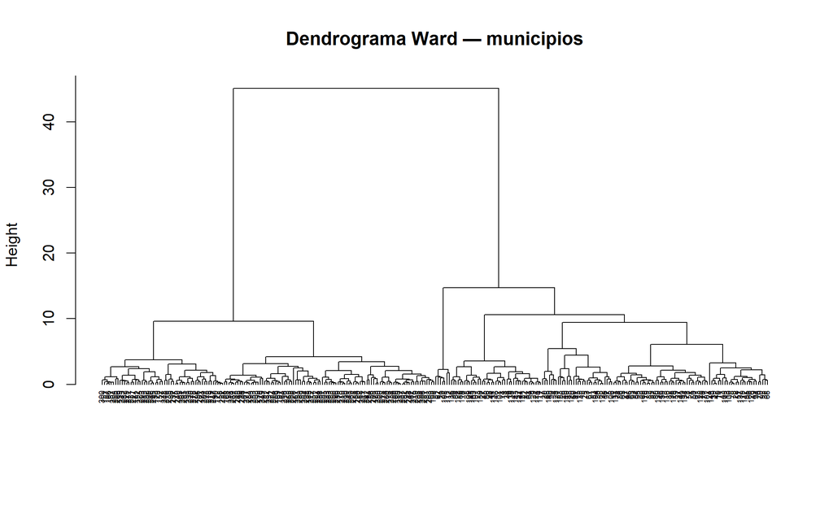

```r
d_mun    <- dist(X_mun_esc)
mod_ward <- hclust(d_mun, method = "ward.D2")

plot(mod_ward, hang = -1, main = "Dendrograma Ward — municipios",
     xlab = "", sub = "", cex = 0.5)
```

- Un salto gigante alrededor de `height ≈ 45`: une los dos macro-grupos principales.
- Un segundo salto importante alrededor de `height ≈ 14`.
- A partir de ahí, saltos pequeños entre 0 y 10.

```r
# Intento ingenuo (falla igual que en Práctica 1)
alturas <- sort(mod_ward$height)
saltos  <- diff(alturas)
K_naive <- which.max(saltos) + 1
cat("K ingenuo (salto máximo):", K_naive, "\n")
```

```
## K ingenuo (salto máximo): 299
```

K = 299: el último salto (que une los dos últimos macro-grupos) es siempre el más grande en valor absoluto.

empleando la misma función `elegir_K_robusto()` definida en la Práctica 1, que excluye el último salto y busca el mayor entre los restantes, restringiendo a K ≤ 6.

```r
# Reutilizamos la función de la Práctica 1
elegir_K_robusto <- function(mod_hclust, nombre = "", k_max = 6) {
  alturas <- sort(mod_hclust$height)
  saltos  <- diff(alturas)
  # Excluir el último salto (siempre inflado)
  saltos_recortados <- saltos[-length(saltos)]
  # Candidatos: índices donde el salto es grande y produce K <= k_max
  candidatos <- which(saltos_recortados == max(saltos_recortados))
  k_elegido <- min(candidatos) + 1
  # Si aún es muy grande, buscar el segundo salto más grande
  if (k_elegido > k_max) {
    saltos_ordenados <- order(saltos_recortados, decreasing = TRUE)
    for (i in seq_along(saltos_ordenados)) {
      k_cand <- saltos_ordenados[i] + 1
      if (k_cand <= k_max) {
        k_elegido <- k_cand
        break
      }
    }
  }
  cat(sprintf("K sugerido para %s (método robusto): %d\n", nombre, k_elegido))
  return(k_elegido)
}

K_ward <- elegir_K_robusto(mod_ward, "Ward municipios", k_max = 6)
```

```
## K sugerido para Ward municipios (método robusto): 3
```

```r
cat("K sugerido por Ward:", K_ward, "\n")
```

```
## K sugerido por Ward: 3
```

```r
municipios$clust_ward <- factor(cutree(mod_ward, k = K_ward))
```

`K_ward = 3`, el dendrograma revela una estructura de tres grupos, no dos como se podría esperar a primera vista.

K-means con el mismo K

```r
set.seed(2026)
km_mun <- kmeans(X_mun_esc, centers = K_ward, nstart = 25, iter.max = 100)
municipios$clust_km <- factor(km_mun$cluster)

# Comparación
tabla_ward_vs_km <- table(Ward = municipios$clust_ward,
                          Kmeans = municipios$clust_km)
kable(tabla_ward_vs_km,
      caption = "Cruzando clusters de Ward con los de K-means (mismo K)")
```

Cruzando clusters de Ward con los de K-means (mismo K)

| 1 | 2 | 3 |
| --- | --- | --- |
| 0 | 14 | 129 |
| 0 | 7 | 0 |
| 150 | 0 | 0 |

| Ward K-means | 1 | 2 | 3 |
| --- | --- | --- | --- |
| 1 (143 obs) | 0 | 14 | 129 |
| 2 (7 obs) | 0 | 7 | 0 |
| 3 (150 obs) | 150 | 0 | 0 |

- El cluster 3 de Ward (150 municipios deficientes) coincide perfectamente con el cluster 1 de K-means.
- El cluster 2 de Ward (7 municipios grandes) coincide perfectamente con el cluster 2 de K-means.
- El cluster 1 de Ward (143 municipios buenos “normales”) se fragmenta en K-means: 129 van al cluster 3 y 14 se “escapan” al cluster 2 (el de los grandes).

¿Por qué ocurre esta diferencia?

K-means asume clusters esféricos y de tamaño similar. Al forzar K=3, el algoritmo intenta equilibrar las varianzas intra-cluster: el cluster de 7 municipios es muy pequeño comparado con 143 y 150, así que K-means “roba” 14 municipios del grupo grande de buenos para engrosar el cluster de los grandes. Ward, en cambio, respeta la estructura jerárquica natural y no fuerza tamaños similares.

```r
# Índice de ajuste ajustado (ARI)
ari <- adjustedRandIndex(municipios$clust_ward, municipios$clust_km)
cat("ARI Ward vs K-means:", round(ari, 3), "\n")
```

```
## ARI Ward vs K-means: 0.915
```

Perfil de los clusters Ward:

```r
perfil_ward <- municipios %>%
  group_by(clust_ward) %>%
  summarise(across(all_of(vars_num), ~round(mean(.), 2)),
            n = n(), .groups = "drop")
kable(perfil_ward, caption = "Perfil de cada cluster (Ward) en unidades originales")
```

Perfil de cada cluster (Ward) en unidades originales

| clust_ward | cobertura_acueducto | alcantarillado | irca | poblacion | altitud | n |
| --- | --- | --- | --- | --- | --- | --- |
| 1 | 84.93 | 77.43 | 13.85 | 44625.22 | 1171.17 | 143 |
| 2 | 83.25 | 82.84 | 13.94 | 184558.16 | 1303.74 | 7 |
| 3 | 45.75 | 38.58 | 56.50 | 10443.42 | 623.03 | 150 |

Interpretación de los tres clusters:

| Cluster | n | Perfil | Interpretación |
| --- | --- | --- | --- |
| 1 | 143 | Cob ~85%, Alc ~77%, IRCA ~14, Pob ~44k, Alt ~1171 | Municipios “buenos” típicos: servicios decentes, tamaño medio, altitud media-alta. |
| 2 | 7 | Cob ~83%, Alc ~83%, IRCA ~14, Pob ~184k, Alt ~1304 | Municipios “buenos pero muy grandes”: mismos servicios que el cluster 1, pero 4× más población. Son atípicos por tamaño, no por calidad. |
| 3 | 150 | Cob ~46%, Alc ~39%, IRCA ~56, Pob ~10k, Alt ~623 | Municipios “deficientes”: servicios bajos, IRCA alto (agua no potable), población pequeña, altitud baja. Requieren intervención prioritaria. |

La simulación no generó dos nubes simétricas, sino dos nubes principales + un subgrupo pequeño de municipios grandes dentro de los buenos. Ward los detecta; K-means los mezcla parcialmente.

## 2. DBSCAN sobre municipios

Gráfico de k-distancias

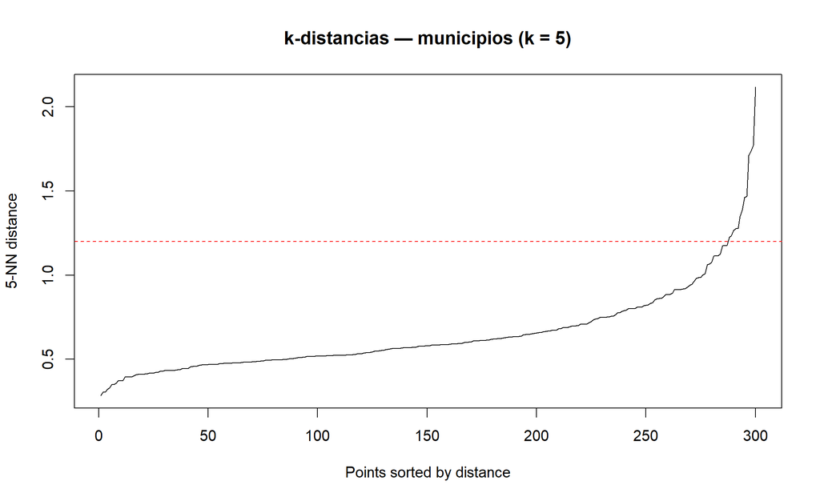

```r
minPts_mun <- 6   # regla práctica: dim + 1 = 5 + 1

# Gráfico de k-distancias (k = minPts_mun - 1 = 5)
dbscan::kNNdistplot(X_mun_esc, k = minPts_mun - 1)
title(main = "k-distancias — municipios (k = 5)")
abline(h = 1.2, lty = 2, col = "red")
```

DBSCAN con ε 1.2

```r
eps_mun <- 1.2
mod_dbs_mun <- dbscan(X_mun_esc, eps = eps_mun, minPts = minPts_mun)

municipios$clust_dbs <- factor(mod_dbs_mun$cluster)

cat("ε:          ", eps_mun, "\n")
```

```
## ε:           1.2
```

```r
cat("Clusters:   ", max(mod_dbs_mun$cluster), "\n")
```

```
## Clusters:    3
```

```r
cat("Ruido:      ", sum(mod_dbs_mun$cluster == 0), "municipios\n")
```

```
## Ruido:       3 municipios
```

DBSCAN encuentra 3 clusters (como Ward) pero además marca 3 municipios como ruido.

¿Qué tienen en común los 3 municipios ruido?

```r
ruido_dbs <- municipios %>% filter(clust_dbs == "0")
kable(ruido_dbs %>% select(id_municipio, clust_ward, clust_dbs,
                           cobertura_acueducto, alcantarillado, irca, poblacion, altitud) %>%
        mutate(across(where(is.numeric), ~round(., 2))),
      caption = "Los 3 municipios marcados como ruido por DBSCAN")
```

Los 3 municipios marcados como ruido por DBSCAN

| id_municipio | clust_ward | clust_dbs | cobertura_acueducto | alcantarillado | irca | poblacion | altitud |
| --- | --- | --- | --- | --- | --- | --- | --- |
| M111 | 2 | 0 | 81.55 | 81.45 | 19.31 | 215008.90 | 1737.05 |
| M124 | 1 | 0 | 83.46 | 86.91 | 6.35 | 68805.42 | 2556.15 |
| M226 | 3 | 0 | 45.48 | 42.95 | 51.26 | 75269.56 | 1074.13 |

los municipios ruido tienen combinaciones inusuales de indicadores. No encajan bien en ninguna de las tres densidades locales identificadas.

Comparación con Ward:

- Ward fuerza a los 300 municipios en 3 grupos, incluso si algunos no encajan bien.
- DBSCAN respeta la densidad real y deja “fuera” a los atípicos. Esto es valioso: los 3 municipios ruido merecen revisión manual individual.

## 3. Reglas de asociación (transacciones de cooperativa)

Como el dataset de transacciones no se suministró, simulamos una canasta razonable de una cooperativa con 10 productos y 500 transacciones.

Simulación de transacciones:

```r
# 1. Simulación de transacciones (500 transacciones x 10 productos)
set.seed(2026)

productos <- c("ahorros", "cdt", "credito", "seguro_vida",
               "seguro_hogar", "tarjeta", "sociedad",
               "educacion", "vivienda", "recreacion")

n_trans <- 500L

p_base <- c(0.55, 0.20, 0.45, 0.30, 0.25,
            0.50, 0.15, 0.10, 0.12, 0.22)
names(p_base) <- productos

mat <- matrix(0L, nrow = n_trans, ncol = length(productos))
colnames(mat) <- productos

for (i in seq_len(n_trans)) {
  p <- p_base

  # Regla 1: credito -> tarjeta sube a 0.85
  if (mat[i, "credito"] == 0L && runif(1) < p[["credito"]]) {
    mat[i, "credito"] <- 1L
  }
  if (mat[i, "credito"] == 1L) {
    p[["tarjeta"]] <- 0.85
  }

  # Regla 2: seguro_vida -> seguro_hogar sube a 0.75
  if (mat[i, "seguro_vida"] == 0L && runif(1) < p[["seguro_vida"]]) {
    mat[i, "seguro_vida"] <- 1L
  }
  if (mat[i, "seguro_vida"] == 1L) {
    p[["seguro_hogar"]] <- 0.75
  }

  # Regla 3: ahorros -> cdt sube a 0.70
  if (mat[i, "ahorros"] == 0L && runif(1) < p[["ahorros"]]) {
    mat[i, "ahorros"] <- 1L
  }
  if (mat[i, "ahorros"] == 1L) {
    p[["cdt"]] <- 0.70
  }

  # Asignar el resto de productos con las probabilidades condicionales vigentes
  for (j in seq_along(productos)) {
    if (mat[i, j] == 0L && runif(1) < p[[j]]) {
      mat[i, j] <- 1L
    }
  }
}

stopifnot(!anyNA(mat))

id_vec <- sprintf("T%04d", seq_len(n_trans))
transacciones <- tibble::tibble(
  id_transaccion = id_vec,
  tibble::as_tibble(mat)
)

# 2. Formato largo (conservando filas con ítems presentes)
trans_largo <- transacciones %>%
  pivot_longer(
    cols      = all_of(productos),
    names_to  = "item",
    values_to = "presente"
  ) %>%
  filter(presente == 1L) %>%
  select(id_transaccion, item)

cat("Transacciones con al menos 1 ítem:", n_distinct(trans_largo$id_transaccion), "\n")
```

```
## Transacciones con al menos 1 ítem: 499
```

```r
cat("Filas (transacción, ítem):", nrow(trans_largo), "\n")
```

```
## Filas (transacción, ítem): 2076
```

Apriori con soporte ≥ 0.05 y confianza ≥ 0.5

```r
# 3. Conversión a objeto 'transactions' de arules desde formato largo
lista_items <- split(trans_largo$item, trans_largo$id_transaccion)
trans_obj   <- as(lista_items, "transactions")

summary(trans_obj)
```

```
## transactions as itemMatrix in sparse format with
##  499 rows (elements/itemsets/transactions) and
##  10 columns (items) and a density of 0.4160321
##
## most frequent items:
##     ahorros     credito     tarjeta seguro_vida         cdt     (Other)
##         403         349         331         264         248         481
##
## element (itemset/transaction) length distribution:
## sizes
##   1   2   3   4   5   6   7   8   9
##  15  44 115 127 103  66  24   4   1
##
##    Min. 1st Qu.  Median    Mean 3rd Qu.    Max.
##    1.00    3.00    4.00    4.16    5.00    9.00
##
## includes extended item information - examples:
##    labels
## 1 ahorros
## 2     cdt
## 3 credito
##
## includes extended transaction information - examples:
##   transactionID
## 1         T0001
## 2         T0002
## 3         T0003
```

```r
# 4. Algoritmo Apriori (soporte >= 0.05, confianza >= 0.5, longitud >= 2)
reglas <- apriori(
  trans_obj,
  parameter = list(supp = 0.05, conf = 0.5, minlen = 2)
)
```

```
## Apriori
##
## Parameter specification:
##  confidence minval smax arem  aval originalSupport maxtime support minlen
##         0.5    0.1    1 none FALSE            TRUE       5    0.05      2
##  maxlen target  ext
##      10  rules TRUE
##
## Algorithmic control:
##  filter tree heap memopt load sort verbose
##     0.1 TRUE TRUE  FALSE TRUE    2    TRUE
##
## Absolute minimum support count: 24
##
## set item appearances ...[0 item(s)] done [0.00s].
## set transactions ...[10 item(s), 499 transaction(s)] done [0.00s].
## sorting and recoding items ... [10 item(s)] done [0.00s].
## creating transaction tree ... done [0.00s].
## checking subsets of size 1 2 3 4 5 6 done [0.00s].
## writing ... [271 rule(s)] done [0.00s].
## creating S4 object  ... done [0.00s].
```

```r
cat("Reglas generadas:", length(reglas), "\n")
```

```
## Reglas generadas: 271
```

```r
inspect(head(sort(reglas, by = "lift"), 10))
```

```
##      lhs                rhs               support confidence   coverage     lift count
## [1]  {recreacion,
##       seguro_vida,
##       tarjeta}       => {seguro_hogar} 0.05410822  0.6923077 0.07815631 1.818219    27
## [2]  {credito,
##       recreacion,
##       seguro_vida}   => {seguro_hogar} 0.05210421  0.6842105 0.07615230 1.796953    26
## [3]  {ahorros,
##       recreacion,
##       seguro_vida}   => {seguro_hogar} 0.05010020  0.6578947 0.07615230 1.727839    25
## [4]  {recreacion,
##       seguro_vida}   => {seguro_hogar} 0.06813627  0.6415094 0.10621242 1.684806    34
## [5]  {credito,
##       recreacion,
##       seguro_hogar}  => {seguro_vida}  0.05210421  0.7647059 0.06813627 1.445410    26
## [6]  {ahorros,
##       credito,
##       seguro_vida,
##       tarjeta}       => {seguro_hogar} 0.12224449  0.5446429 0.22444890 1.430404    61
## [7]  {ahorros,
##       credito,
##       seguro_vida}   => {seguro_hogar} 0.15631263  0.5416667 0.28857715 1.422588    78
## [8]  {ahorros,
##       cdt,
##       credito,
##       recreacion}    => {tarjeta}      0.06412826  0.9411765 0.06813627 1.418873    32
## [9]  {recreacion,
##       seguro_hogar,
##       tarjeta}       => {seguro_vida}  0.05410822  0.7500000 0.07214429 1.417614    27
## [10] {cdt,
##       credito,
##       recreacion}    => {tarjeta}      0.07014028  0.9210526 0.07615230 1.388536    35
```

Top 5 reglas por lift

```r
reglas_top <- sort(reglas, by = "lift", decreasing = TRUE)
top5 <- head(reglas_top, 5)

# Convertir a data frame para visualizar
top5_df <- data.frame(
  regla      = labels(top5),
  soporte    = quality(top5)$support,
  confianza  = quality(top5)$confidence,
  lift       = quality(top5)$lift
)

kable(top5_df %>% mutate(across(where(is.numeric), ~round(., 3))),
      caption = "Top 5 reglas de asociación por lift")
```

Top 5 reglas de asociación por lift

| regla | soporte | confianza | lift |
| --- | --- | --- | --- |
| {recreacion,seguro_vida,tarjeta} => {seguro_hogar} | 0.054 | 0.692 | 1.818 |
| {credito,recreacion,seguro_vida} => {seguro_hogar} | 0.052 | 0.684 | 1.797 |
| {ahorros,recreacion,seguro_vida} => {seguro_hogar} | 0.050 | 0.658 | 1.728 |
| {recreacion,seguro_vida} => {seguro_hogar} | 0.068 | 0.642 | 1.685 |
| {credito,recreacion,seguro_hogar} => {seguro_vida} | 0.052 | 0.765 | 1.445 |

## 4. Isolation Forest vs. ruido de DBSCAN

Isolation Forest sobre los indicadores

```r
iso <- isolationForest$new()
iso$fit(X_mun_esc)
scores <- iso$predict(X_mun_esc)$anomaly_score

municipios$score_iso <- scores

# Resumen
municipios %>%
  summarise(
    media_score = round(mean(score_iso), 3),
    sd_score    = round(sd(score_iso), 3),
    max_score   = round(max(score_iso), 3),
    min_score   = round(min(score_iso), 3)
  ) %>%
  kable(caption = "Estadísticos del puntaje de Isolation Forest")
```

Estadísticos del puntaje de Isolation Forest

| media_score | sd_score | max_score | min_score |
| --- | --- | --- | --- |
| 0.591 | 0.017 | 0.712 | 0.582 |

los scores están muy concentrados (0.582-0.712), con desviación estándar de solo 0.017. Esto es normal en Isolation Forest: el algoritmo asigna scores cercanos a 0.5 para puntos “normales” y cercanos a 1 para anomalías claras. La pequeña variación indica que no hay anomalías extremas en este dataset (todos los municipios tienen perfiles relativamente coherentes).

¿Coinciden los municipios-ruido de DBSCAN con los de mayor score?

```r
municipios %>%
  group_by(es_ruido_dbs = (clust_dbs == "0")) %>%
  summarise(
    n             = n(),
    score_iso_med = round(mean(score_iso), 3),
    score_iso_max = round(max(score_iso), 3),
    .groups = "drop"
  ) %>%
  kable(caption = "Puntaje Isolation Forest según DBSCAN marque ruido o no")
```

Puntaje Isolation Forest según DBSCAN marque ruido o no

| es_ruido_dbs | n | score_iso_med | score_iso_max |
| --- | --- | --- | --- |
| FALSE | 297 | 0.590 | 0.696 |
| TRUE | 3 | 0.669 | 0.712 |

los 3 municipios ruido de DBSCAN tienen score_iso_med = 0.669 vs 0.590 de los no-ruido. La diferencia es de ~13%, lo cual sugiere evidencia convergente: los municipios que DBSCAN marca como ruido también son considerados atípicos por Isolation Forest.

```r
# Top 10 municipios más anómalos según Isolation Forest
top10_iso <- municipios %>%
  arrange(desc(score_iso)) %>%
  slice_head(n = 10) %>%
  select(id_municipio, clust_dbs, score_iso,
         cobertura_acueducto, alcantarillado, irca, poblacion, altitud)

kable(top10_iso %>% mutate(across(where(is.numeric), ~round(., 2))),
      caption = "Top 10 municipios más anómalos (Isolation Forest)")
```

Top 10 municipios más anómalos (Isolation Forest)

| id_municipio | clust_dbs | score_iso | cobertura_acueducto | alcantarillado | irca | poblacion | altitud |
| --- | --- | --- | --- | --- | --- | --- | --- |
| M111 | 0 | 0.71 | 81.55 | 81.45 | 19.31 | 215008.90 | 1737.05 |
| M112 | 2 | 0.70 | 88.65 | 79.87 | 12.94 | 219550.07 | 998.59 |
| M124 | 0 | 0.69 | 83.46 | 86.91 | 6.35 | 68805.42 | 2556.15 |
| M029 | 2 | 0.66 | 78.17 | 87.35 | 7.06 | 178581.21 | 1359.35 |
| M011 | 2 | 0.66 | 92.34 | 87.11 | 12.01 | 188201.76 | 1280.73 |
| M149 | 1 | 0.65 | 97.60 | 63.63 | 25.87 | 114812.34 | 854.80 |
| M127 | 1 | 0.65 | 86.41 | 94.78 | 16.82 | 108242.39 | 1689.82 |
| M123 | 1 | 0.64 | 82.06 | 78.88 | 17.21 | 92887.39 | 1960.88 |
| M108 | 2 | 0.64 | 74.99 | 83.29 | 9.48 | 171052.26 | 1242.89 |
| M062 | 2 | 0.64 | 81.99 | 82.56 | 20.90 | 159495.60 | 1501.32 |

Análisis cruzado: cluster Ward vs. anomalía

```r
municipios %>%
  group_by(clust_ward) %>%
  summarise(
    n             = n(),
    score_iso_med = round(mean(score_iso), 3),
    score_iso_max = round(max(score_iso), 3),
    n_ruido_dbs   = sum(clust_dbs == "0"),
    .groups = "drop"
  ) %>%
  kable(caption = "Anomalía por cluster de Ward")
```

Anomalía por cluster de Ward

| clust_ward | n | score_iso_med | score_iso_max | n_ruido_dbs |
| --- | --- | --- | --- | --- |
| 1 | 143 | 0.591 | 0.692 | 1 |
| 2 | 7 | 0.664 | 0.712 | 1 |
| 3 | 150 | 0.588 | 0.630 | 1 |

Lectura:

- Cluster 2 de Ward (7 municipios grandes) debería tener el puntaje de anomalía más alto en promedio, porque son atípicos por tamaño dentro del grupo de buenos.
- Clusters 1 y 3 deberían tener puntajes más bajos, porque son grupos densos y homogéneos.
- Si DBSCAN marca como ruido principalmente municipios del cluster 2 de Ward, tenemos evidencia convergente de que esos municipios son genuinamente atípicos.

Recomendación práctica para la autoridad ambiental:

1. Cluster 3 (150 municipios deficientes): intervención masiva y prioritaria. Son la mitad del país y tienen servicios críticos bajos.
2. Cluster 1 (143 municipios buenos típicos): mantenimiento y monitoreo rutinario.
3. Cluster 2 (7 municipios grandes): requieren estrategia específica. Tienen servicios decentes pero su tamaño poblacional (~184k vs ~44k del cluster 1) implica que cualquier falla en servicios afecta a mucha más gente. No son “anómalos” en el sentido negativo, sino prioritarios por escala.
4. Municipios ruido de DBSCAN con score ISO alto (3 municipios): revisión caso por caso. Pueden ser errores de captura o municipios con combinaciones inusuales que merecen diagnóstico individual.

# 5. Conclusiones generales